# Analysis of Professor salaries

Nick Cianci

November 27, 2017

```r
#Load in relevant packages
library('DataComputing')
library('knitr')
library('mosaic')
library('readr')
library('dplyr')
library('graphics')
```

# The Data

The dataset I chose was a csv file of Salaries of Professors with PhD’s. I obtained the dataset from the webstite https://vincentarelbundock.github.io/Rdatasets/datasets.html

```r
#Read in Professor's salary data and look at the structure of the data

raw_data2 <- read_csv('https://raw.githubusercontent.com/vincentarelbundock/Rdatasets/master/csv/car/Salaries.csv')

str(raw_data2)
```

```
## Classes 'tbl_df', 'tbl' and 'data.frame':    397 obs. of  7 variables:
##  $ X1           : int  1 2 3 4 5 6 7 8 9 10 ...
##  $ rank         : chr  "Prof" "Prof" "AsstProf" "Prof" ...
##  $ discipline   : chr  "B" "B" "B" "B" ...
##  $ yrs.since.phd: int  19 20 4 45 40 6 30 45 21 18 ...
##  $ yrs.service  : int  18 16 3 39 41 6 23 45 20 18 ...
##  $ sex          : chr  "Male" "Male" "Male" "Male" ...
##  $ salary       : int  139750 173200 79750 115000 141500 97000 175000 147765 119250 129000 ...
##  - attr(*, "spec")=List of 2
##   ..$ cols   :List of 7
##   .. ..$ X1           : list()
##   .. .. ..- attr(*, "class")= chr  "collector_integer" "collector"
##   .. ..$ rank         : list()
##   .. .. ..- attr(*, "class")= chr  "collector_character" "collector"
##   .. ..$ discipline   : list()
##   .. .. ..- attr(*, "class")= chr  "collector_character" "collector"
##   .. ..$ yrs.since.phd: list()
##   .. .. ..- attr(*, "class")= chr  "collector_integer" "collector"
##   .. ..$ yrs.service  : list()
##   .. .. ..- attr(*, "class")= chr  "collector_integer" "collector"
##   .. ..$ sex          : list()
##   .. .. ..- attr(*, "class")= chr  "collector_character" "collector"
##   .. ..$ salary       : list()
##   .. .. ..- attr(*, "class")= chr  "collector_integer" "collector"
##   ..$ default: list()
##   .. ..- attr(*, "class")= chr  "collector_guess" "collector"
##   ..- attr(*, "class")= chr "col_spec"
```

By looking at the structure of the data, you can see that their are 397 observations with 7 attributes however the first attribute is simply an index of the records and was not used throughout the project. The attributes used were rank, discipline, yrs.since.phd, yrs.service, sex, and salary. Rank, discipline and sex are characters while yrs.since.phd, yrs.service, and salary are integers.

Lets take a look at the first 6 records in the dataset

```r
#A quick look at the data
kable(head(raw_data2))
```

| X1 | rank | discipline | yrs.since.phd | yrs.service | sex | salary |
| --- | --- | --- | --- | --- | --- | --- |
| 1 | Prof | B | 19 | 18 | Male | 139750 |
| 2 | Prof | B | 20 | 16 | Male | 173200 |
| 3 | AsstProf | B | 4 | 3 | Male | 79750 |
| 4 | Prof | B | 45 | 39 | Male | 115000 |
| 5 | Prof | B | 40 | 41 | Male | 141500 |
| 6 | AssocProf | B | 6 | 6 | Male | 97000 |

# Creating a new dataframe

```r
#drop the first row
rank <- raw_data2$rank
discipline <- raw_data2$discipline
yr_since_phd <- raw_data2$yrs.since.phd
yrs_service <- raw_data2$yrs.service
sex <- raw_data2$sex
salary <- raw_data2$salary



#create a new dataset without the first column
df2 <- data.frame(rank, discipline, yr_since_phd, yrs_service,sex, salary)
kable(head(df2))
```

| rank | discipline | yr_since_phd | yrs_service | sex | salary |
| --- | --- | --- | --- | --- | --- |
| Prof | B | 19 | 18 | Male | 139750 |
| Prof | B | 20 | 16 | Male | 173200 |
| AsstProf | B | 4 | 3 | Male | 79750 |
| Prof | B | 45 | 39 | Male | 115000 |
| Prof | B | 40 | 41 | Male | 141500 |
| AssocProf | B | 6 | 6 | Male | 97000 |

# Linear Regression Scatterplots

I started by exploring the data for relationships between variables by performing linear regression.

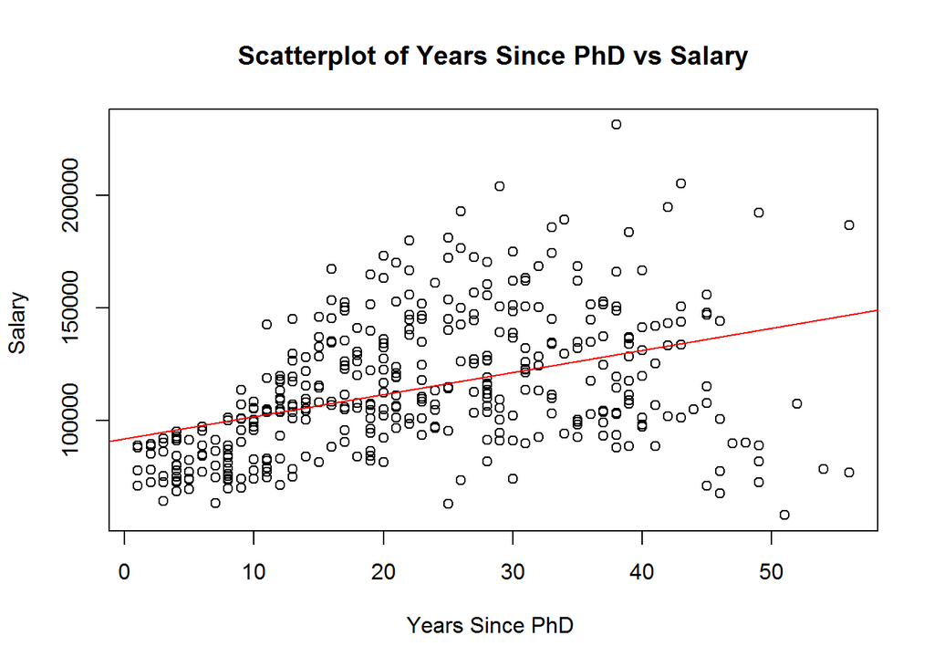

```r
#Create a scatterplot of years since phd vs salary

plot(yr_since_phd, salary, main="Scatterplot of Years Since PhD vs Salary",
    xlab="Years Since PhD ", ylab="Salary ")

#Overlay the linear regression line
abline(lm(salary~yr_since_phd), col="red")
```

```r
#Produce summary of linear regression
reg1 <- lm(salary~yr_since_phd,data=df2)
summary(reg1)
```

```
##
## Call:
## lm(formula = salary ~ yr_since_phd, data = df2)
##
## Residuals:
##    Min     1Q Median     3Q    Max
## -84171 -19432  -2858  16086 102383
##
## Coefficients:
##              Estimate Std. Error t value Pr(>|t|)
## (Intercept)   91718.7     2765.8  33.162   <2e-16 ***
## yr_since_phd    985.3      107.4   9.177   <2e-16 ***
## ---
## Signif. codes:  0 '***' 0.001 '**' 0.01 '*' 0.05 '.' 0.1 ' ' 1
##
## Residual standard error: 27530 on 395 degrees of freedom
## Multiple R-squared:  0.1758, Adjusted R-squared:  0.1737
## F-statistic: 84.23 on 1 and 395 DF,  p-value: < 2.2e-16
```

As you can see from the graph and the summary, the salary and years since phd are weakly positively correlated. This means that the more years since phd means a higher salary.

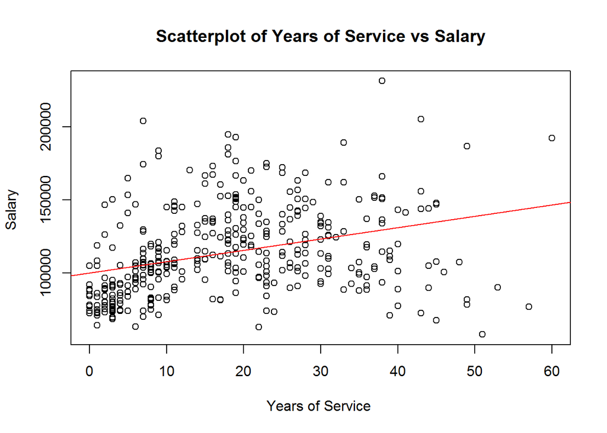

```r
#Scatter Plot of years of service vs salary
plot(yrs_service, salary, main="Scatterplot of Years of Service vs Salary",
    xlab="Years of Service ", ylab="Salary ")

#Overlays the linear regression line
abline(lm(salary~yrs_service), col="red")
```

```r
#Creates summary statistics
reg2 <- lm(salary~yrs_service,data=df2)
summary(reg2)
```

```
##
## Call:
## lm(formula = salary ~ yrs_service, data = df2)
##
## Residuals:
##    Min     1Q Median     3Q    Max
## -81933 -20511  -3776  16417 101947
##
## Coefficients:
##             Estimate Std. Error t value Pr(>|t|)
## (Intercept)  99974.7     2416.6   41.37  < 2e-16 ***
## yrs_service    779.6      110.4    7.06 7.53e-12 ***
## ---
## Signif. codes:  0 '***' 0.001 '**' 0.01 '*' 0.05 '.' 0.1 ' ' 1
##
## Residual standard error: 28580 on 395 degrees of freedom
## Multiple R-squared:  0.1121, Adjusted R-squared:  0.1098
## F-statistic: 49.85 on 1 and 395 DF,  p-value: 7.529e-12
```

Years of service agaisnt salary is slightly positively correlated as well. This means that the more years of service the higher the salary. In comparison Years since phd had a stronger relationship with salary than years of service did however both were very weak.

# Does longevity mean a bigger payday?

I was interested in exploring whether or not the amount of years since obtaining a PhD or the amount of years of service affected the salary size for Professors. I created multiple graphs in an attempt to uncover any hidden trends.

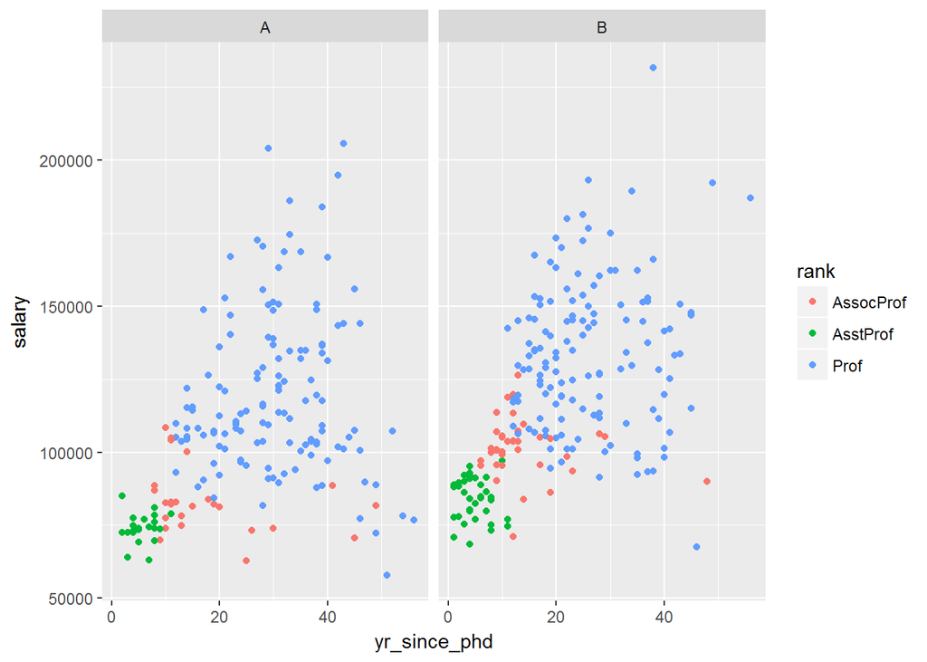

```r
#scatter plot of the relationships between salary and years since obtaining a phd, colored by different rank and faceted by discipline
ggplot(data= df2 ,aes(x=yr_since_phd, y=salary))+geom_point()+aes(colour = rank)+facet_wrap(~discipline)
```

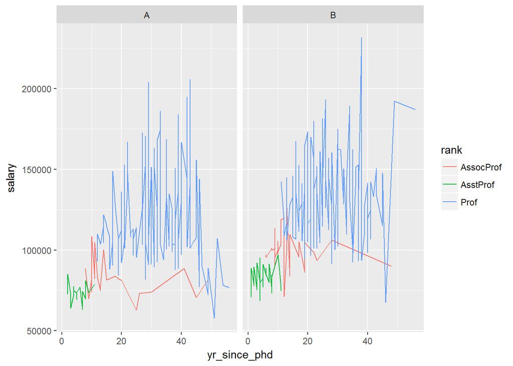

```r
#line plot of the relationships between salary and years since obtaining a phd, colored by different rank and faceted by discipline
ggplot(data= df2 ,aes(x=yr_since_phd, y=salary))+geom_line()+aes(colour = rank)+facet_wrap(~discipline)
```

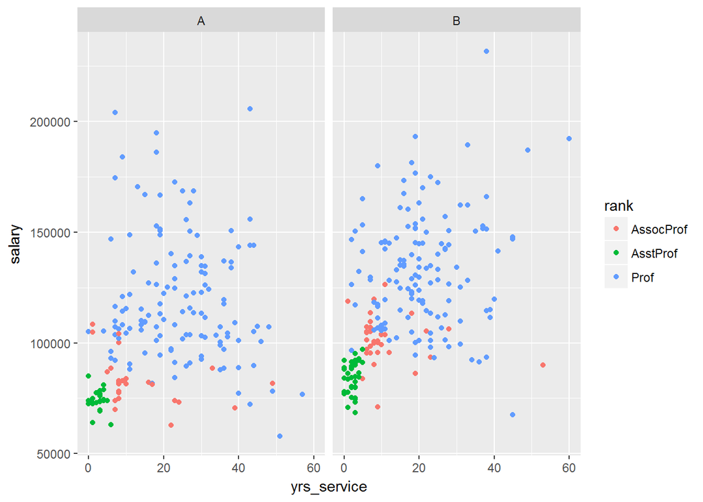

```r
#scatterplot of the relationships between salary and years of service, colored by different rank and faceted by discipline
ggplot(data= df2 ,aes(x= yrs_service , y=salary))+geom_point()+aes(colour = rank)+facet_wrap(~discipline)
```

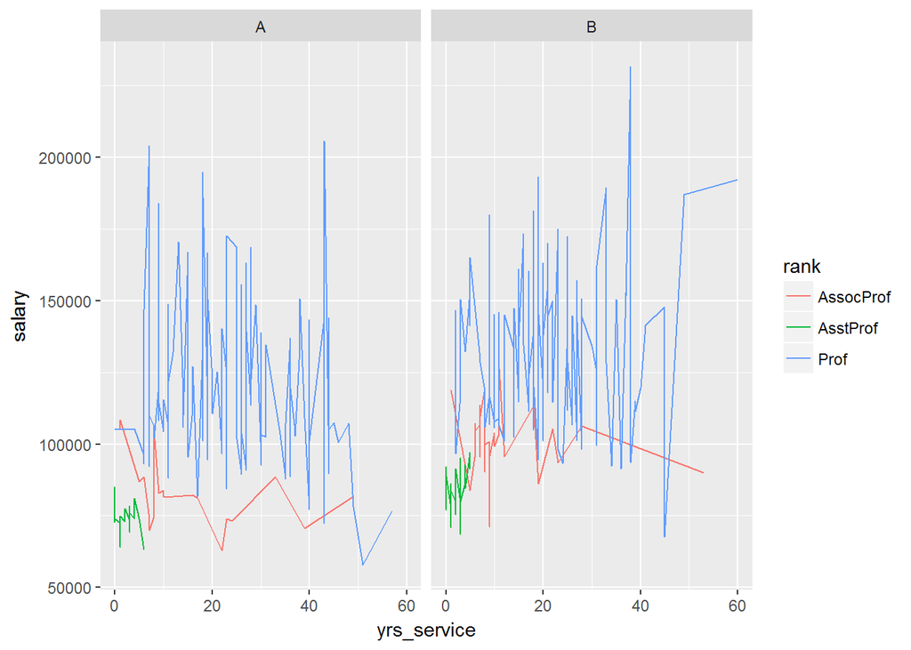

```r
#line plot of the relationships between salary and years of service, colored by different rank and faceted by discipline
ggplot(data= df2 ,aes(x=yrs_service, y=salary))+geom_line()+aes(colour = rank)+facet_wrap(~discipline)
```

What I can conclude from these graphs is that generally, the more years of service correlates to a higher salary. The graphs for years since obtaining a PhD were strikingly similar to the graphs for years of service and thus have the same conclusions. I also concluded that the rank of the professor (Associate, Assistant, Professor) is a much better indicator of salary than the years of service or years since PhD, as one would expect.Their doesn’t seem to be any significant difference in salary distribution based on the discipline of the professors.

# Do Male Professors make more than Female Professors?

```r
#Filters the dataframe for only males
male_sal <- df2 %>%
  filter(sex == 'Male')

#Max salary of males
max(male_sal$salary)
```

```
## [1] 231545
```

```r
#Min salary for males
min(male_sal$salary)
```

```
## [1] 57800
```

```r
#Average salary for males
mean(male_sal$salary)
```

```
## [1] 115090.4
```

```r
#Filters the dataframe for only females
female_sal <- df2 %>%
  filter(sex == 'Female')

#Max salary for females
max(female_sal$salary)
```

```
## [1] 161101
```

```r
#Min salary for females
min(female_sal$salary)
```

```
## [1] 62884
```

```r
#Average Salary for females
mean(female_sal$salary)
```

```
## [1] 101002.4
```

```r
#Count of females
count(female_sal)
```

```
## # A tibble: 1 x 1
##       n
##   <int>
## 1    39
```

```r
#Count of males
count(male_sal)
```

```
## # A tibble: 1 x 1
##       n
##   <int>
## 1   358
```

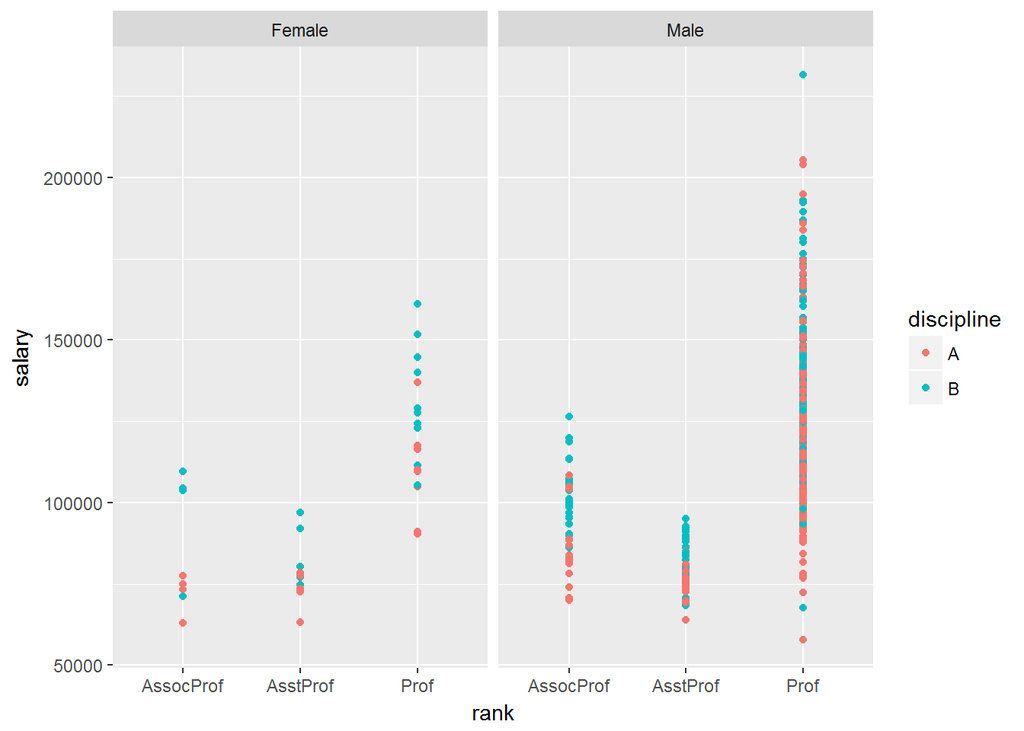

```r
#bar plot of the relationships between salary and years since obtaining a phd, colored by different rank and faceted by discipline
ggplot(data= df2 ,aes(x=rank, y= salary))+geom_point()+aes(colour = discipline)+facet_wrap(~sex)
```

As the calculations and the plot suggest, Male professors seem to make higher salaries than Female professors. The Male professor makes $14,088 more on average than their female counterparts. Meanwhile,the highest recorded salary also belonged to a male professor coming in at $231,545, an eyepopping $70,444 more than the largest female professor salary. It is also noteworthy that their were 358 male Professors with PhD’s and only 39 female Professors with PhD’s.